# Relatório de desempenho dos alunos no Exame Nacional de Ensino Médio (ENEM) por município

Elaborado por: Marcio Vakassugui

01-07-2022

# Objetivo

Elaborar um modelo de relatório em HTML, produzido em RMarkdown, que apresente visualizações de desempenho dos alunos na prova do Exame Nacional do Ensino Médio (ENEM) por município.

O modelo deve ter a característica de reprodutibilidade, de modo que cada relatório (formato, textos e visualizações) seja produzido a partir de uma rotina de procedimentos (*script*) de forma automatizada para todos os 88 municípios do estado do Paraná, nos quais as provas foram realizadas.

# Informações Gerais

### Dados do exame

| Município: Curitiba | Estado: PR |
| --- | --- |

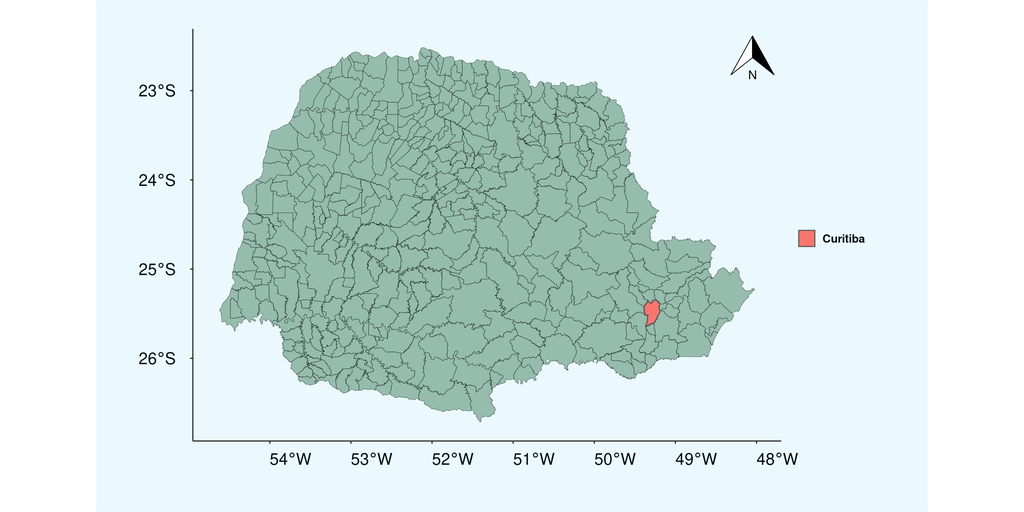

| Alunos classificados: 21892 | Ano do exame: 2020 |
| --- | --- |

```r
dados_geobr |>
  dplyr::filter(name_muni == params$cidade) |>
  ggplot2::ggplot() +
  ggplot2::geom_sf(
    data = dados_geobr,
    fill = "#70A288",
    color = "#000000",
    size = .1,
    alpha = 0.7
  ) +
  ggplot2::geom_sf(ggplot2::aes(fill = name_muni)) +
  ggspatial::annotation_north_arrow(location = "tr") +
  ggplot2::theme_classic() +
  theme_enem() +
  ggplot2::theme(
    legend.title = ggplot2::element_blank(),
    legend.background = ggplot2::element_rect(
      fill = "#EBF9FF",
      colour = "#EBF9FF"
    )
  )
```

# Prova de redação

### Distribuição das notas de redação

As notas das redações variam de 0 a 1000 pontos. No gráfico 01, pode-se visualizar por meio do boxPlot e do histograma a média e a distribuição das notas.

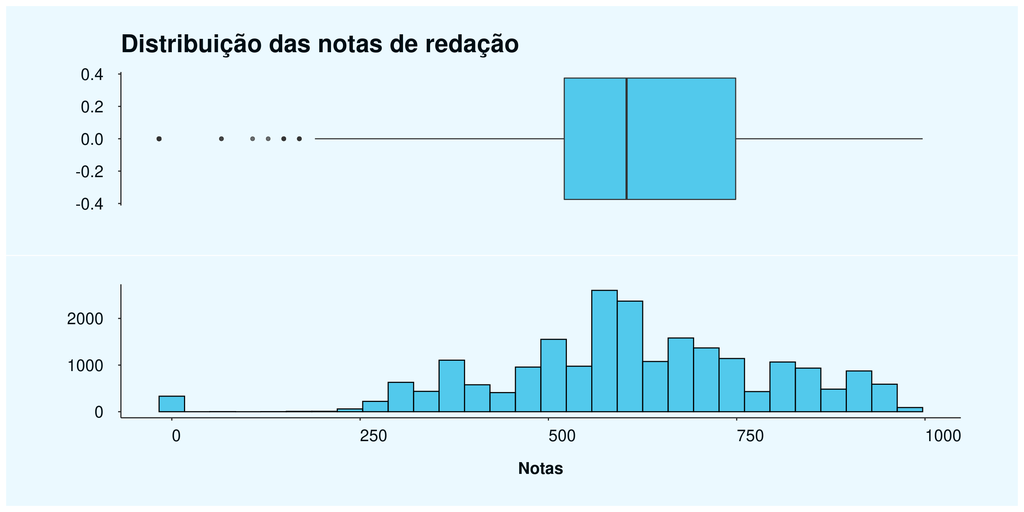

Gráfico 01 - BoxPlot e histograma da distribuição de notas de redação

```r
# carregar a biblioteca patchwork
library(patchwork)   # para união dos gráficos

# gráfico do boxplot das notas das redações (parte superior da visualização)
p1_1 <- enem_cidade |>
  dplyr::select(nu_nota_redacao) |>
  ggplot2::ggplot(ggplot2::aes(x = nu_nota_redacao)) +
  ggplot2::geom_boxplot(
    fill = "#11B5E4",
    alpha = 0.7
  ) +
  ggplot2::labs(
    title = "Distribuição das notas de redação ",
    x = "",
    y = ""
  ) +
  ggplot2::theme_classic() +
  theme_enem() +
  ggplot2::theme(
    axis.ticks.x = ggplot2::element_blank(),
    axis.line.x = ggplot2::element_blank(),
    axis.text.x = ggplot2::element_blank()
  )

# gráfico do histograma das notas das redações (parte inferior da visualização)
p1_2 <- enem_cidade |>
  dplyr::select(nu_nota_redacao) |>
  ggplot2::ggplot(ggplot2::aes(x = nu_nota_redacao)) +
  ggplot2::geom_histogram(
    fill = "#11B5E4",
    color = "#000000",
    alpha = 0.7
  ) +
  ggplot2::labs(
    x = "Notas",
    y = ""
  ) +
  ggplot2::theme_classic() +
  theme_enem()


# disposição dos gráficos
p1 <- p1_1/p1_2
p1
```

Entre os alunos que realizaram o exame na cidade de **Curitiba**, a maior nota **980** foi conquistada por 90 aluno(s). A nota média foi de **611.475**.

### Distribuição das notas das redações por intervalo de classes.

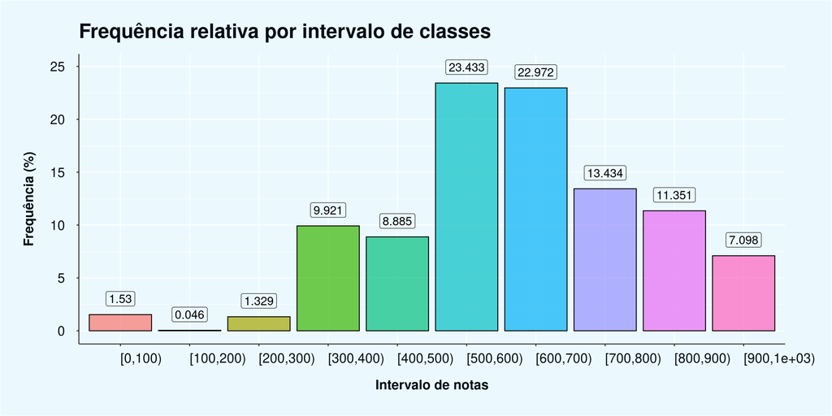

Gráfico 02 - Diagrama de colunas da distribuição de notas por intervalos

```r
p2 <- tab_classes_notas |>
  ggplot2::ggplot() +
  ggplot2::aes(
    x = Var1,
    y = Freq,
    fill = Var1,
    label = round(Freq, 3)
  ) +
  ggplot2::geom_col(
    color = "#000000",
    alpha = 0.7
  ) +
  ggplot2::geom_label( # labels
    size = 5,
    color = "#000000",
    alpha = 0,
    nudge_y = 1.5
  ) +
  ggplot2::labs( # títulos dos eixos
    title = "Frequência relativa por intervalo de classes",
    x = "Intervalo de notas",
    y = "Frequência (%)"
  ) +
  ggplot2::theme(legend.position = "none") +
  ggplot2::scale_colour_viridis_d(option = "E") +
  theme_enem()

p2
```

No gráfico 02, pode-se observar melhor como as notas de redação se distribuíram entre os valores de 0 a 1000. Os valores mostram o percentual de notas de cada intervalo. Valores maiores indicam a proporção de notas mais comuns.

### Principais razões para se atribuir nota 0 (zero) a redação

A banca avaliadora atribui nota 0 (zero) de acordo com as seguintes causas:

- Não atendimento ao tipo: a redação que possua outra estrutura textual que não seja a estrutura dissertativo-argumentativo;
- Fuga ao tema: a que não atende à proposta solicitada;
- Em branco: a que não apresente texto escrito na folha de redação;
- Texto insuficiente: a que apresente até 7 linhas, qualquer que seja o conteúdo;
- Parte desconectada: a que apresenta parte do texto deliberadamente desconectada com o tema proposto;
- Anulada: a que apresenta impropérios, desenhos ou outras formas propositais de anulação, números ou sinais gráficos sem função clara em qualquer parte do texto ou em qualquer parte da folha de redação; com assinatura, nome, iniciais, apelido, codinome ou rubrica fora do local devidamente designado para a assinatura do participante; com texto predominantemente ou integralmente escrito em língua estrangeira; ou com texto ilegível, que impossibilite sua leitura por dois avaliadores independentes e
- Cópia Texto Motivador: a que contenha cópia de texto(s) da prova de redação e/ou do caderno de questões sem que haja pelo menos 8 linhas de produção própria do participante;

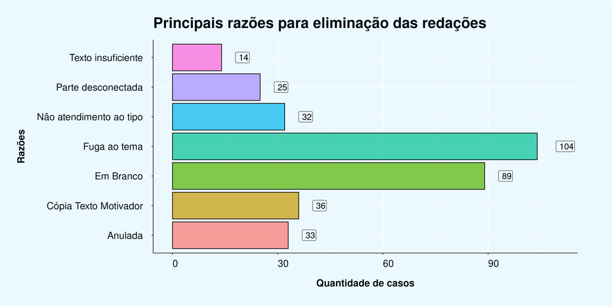

Gráfico 03 - Diagrama de barras razões para notas zero

```r
redacoes_com_problemas <- enem_cidade |>
  dplyr::filter(nu_nota_redacao == 0) |>
  dplyr::group_by(tp_status_redacao) |>
  dplyr::summarise(qte = dplyr::n()) |>
  dplyr::mutate(tp_status_redacao = as.factor(tp_status_redacao))


p3 <- redacoes_com_problemas |>
  ggplot2::ggplot(ggplot2::aes(
    x = qte,
    y = tp_status_redacao,
    fill = tp_status_redacao,
    label = qte
  )) +
  ggplot2::geom_col(
    color = "#000000",
    alpha = 0.7
  ) +
  ggplot2::geom_label( # labels
    size = 5,
    color = "#000000",
    alpha = 0,
    hjust = -1
  ) +
  ggplot2::labs( # títulos dos eixos
    title = "Principais razões para eliminação das redações",
    x = "Quantidade de casos",
    y = "Razões"
  ) +
  ggplot2::scale_x_continuous(limits = c(0, max(redacoes_com_problemas$qte) + 6)) +
  ggplot2::scale_color_viridis_d(option = "E") +
  ggplot2::theme(legend.position = "none") +
  theme_enem()

p3
```

O total de **333** participante(s), entre os **21892** aluno(s), obtiveram nota zero , o que representa um percentual de **1.521%**. *Fuga ao tema* foi a principal causa de notas zero nas redações dos alunos de Curitiba , com **104** casos.

### Notas médias das competências

A nota da redação é composta por cinco competências com notas que variam de 0 a 200 pontos. A soma das seguintes competências resulta na nota final da redação do aluno.

- Demonstrar domínio da modalidade escrita formal da Língua Portuguesa;
- Compreender a proposta de redação e aplicar conceitos das várias áreas de conhecimento para desenvolver o tema, dentro dos limites estruturais do texto dissertativo-argumentativo em prosa;
- Selecionar, relacionar, organizar e interpretar informações, fatos, opiniões e argumentos em defesa de um ponto de vista;
- Demonstrar conhecimento dos mecanismos linguísticos necessários para a construção da argumentação;
- Elaborar proposta de intervenção para o problema abordado, respeitando os direitos humanos.

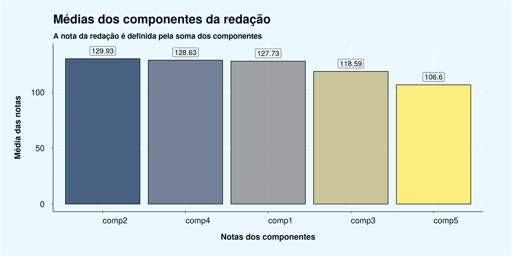

Gráfico 04 - Média das notas por competências das redações

```r
# Cosntruir o gráfico de barras das médias dos componentes que compõem a nota da redação
p4 <- medias_comp_redacao |> # base
  dplyr::mutate(
    notas_comp_redacao = forcats::fct_reorder(
      notas_comp_redacao,
      medias,
      .desc = TRUE
    )
  ) |>
  ggplot2::ggplot() + # gráfico
  ggplot2::aes(
    x = notas_comp_redacao,
    y = medias,
    fill = notas_comp_redacao,
    label = round(medias, 2)
  ) +
  ggplot2::geom_col(
    color = "#000000",
    alpha = 0.7
  ) +
  ggplot2::geom_label( # labels
    size = 5,
    color = "#000000",
    alpha = 0,
    nudge_y = 7
  ) +
  ggplot2::labs( # títulos dos eixos
    title = "Médias dos componentes da redação",
    subtitle = "A nota da redação é definida pela soma dos componentes",
    x = "Notas dos componentes",
    y = "Média das notas"
  ) + # tema
  ggplot2::theme(
    legend.position = "none"
  ) +
  theme_enem()+
  ggplot2::scale_fill_viridis_d(option = "E")

p4
```

Os alunos obtiveram o melhor desempenho na competência dois da redação, compreender a proposta de redação e aplicar conceitos das várias áreas de conhecimento para desenvolver o tema, dentro dos limites estruturais do texto dissertativo-argumentativo em prosa, com a média de **129.93** e o pior desempenho na competência cinco, elaborar proposta de intervenção para o problema abordado, respeitando os direitos humanos, com a média de **106.6**.

### Distribuição das notas por competências

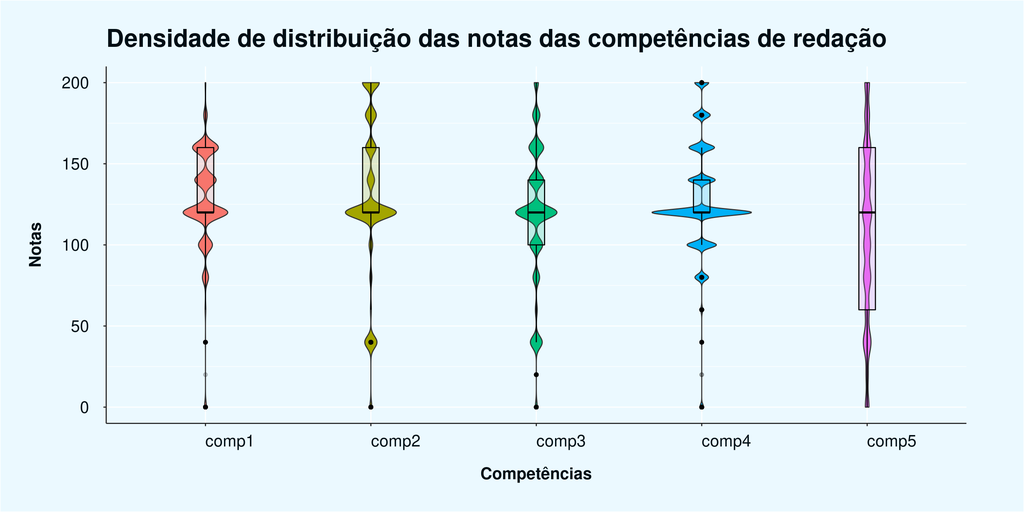

Gráfico 05 - ViolinPlot e BoxPlot das competências das notas de redação

```r
p5 <- comp_redacao_long |>
  ggplot2::ggplot(ggplot2::aes(competencias,
    notas_comp,
    fill = competencias
  )) +
  ggplot2::geom_violin(width = 0.6) +
  ggplot2::geom_boxplot(
    width = 0.1,
    color = "black",
    alpha = 0.2
  ) +
  ggplot2::labs(
    title = "Densidade de distribuição das notas das competências de redação",
    x = "Competências",
    y = "Notas"
  ) +
  theme_enem() +
  ggplot2::theme(legend.position = "none")

p5
```

### Evolução das notas das redações nos últimos anos

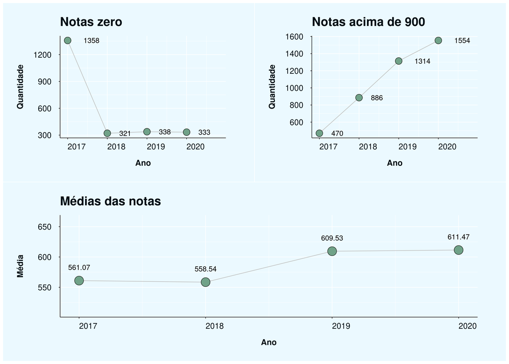

Gráfico 06 - Gráfico de linhas - evolução das notas

```r
p6_1 <- enem_redacao_historico |>
  ggplot2::ggplot() +
  ggplot2::aes(
    x = nu_ano,
    y = media,
    label = round(media, 2)
  ) +
  ggplot2::geom_line(color = "grey") +
  ggplot2::geom_point(
    shape = 21,
    color = "black",
    fill = "#70A288",
    size = 8
  ) +
  ggplot2::geom_text(
    vjust = -2,
    size = 5
  ) +
  theme_enem() +
  ggplot2::labs(
    title = "Médias das notas",
    x = "Ano",
    y = "Média"
  ) +
  ggplot2::scale_y_continuous(limits = c(
    min(enem_redacao_historico$media) - 50,
    max(enem_redacao_historico$media) + 50
  ))


p6_2 <- enem_redacao_historico_notas900 |>
  ggplot2::ggplot() +
  ggplot2::aes(
    x = nu_ano,
    y = qtde,
    label = qtde
  ) +
  ggplot2::geom_line(color = "grey") +
  ggplot2::geom_point(
    shape = 21,
    color = "black",
    fill = "#70A288",
    size = 6
  ) +
  ggplot2::geom_text(
    hjust = -1,
    size = 5
  ) +
  theme_enem() +
  ggplot2::labs(
    title = "Notas acima de 900",
    x = "Ano",
    y = "Quantidade"
  ) +
  ggplot2::scale_x_continuous(limits = c(
    min(enem_redacao_historico_notas900$nu_ano),
    max(enem_redacao_historico_notas900$nu_ano) + 0.8
  ))

p6_3 <- enem_notas_zero |>
  ggplot2::ggplot() +
  ggplot2::aes(
    x = nu_ano,
    y = qtde,
    label = qtde
  ) +
  ggplot2::geom_line(
    color = "grey"
  ) +
  ggplot2::geom_point(
    shape = 21,
    color = "black",
    fill = "#70A288",
    size = 6
  ) +
  ggplot2::geom_text(
    hjust = -1,
    size = 5
  ) +
  theme_enem() +
  ggplot2::labs(
    title = "Notas zero",
    x = "Ano",
    y = "Quantidade"
  ) +
  ggplot2::scale_x_continuous(limits = c(
    min(enem_redacao_historico_notas900$nu_ano),
    max(enem_redacao_historico_notas900$nu_ano) + 0.8
  ))

library(patchwork)

p6 <-  (p6_3 + p6_2) / p6_1

p6
```

# Prova de Linguagens e Códigos

A prova de linguagens possui 45 questões, sendo 5 de língua estrangeira.

### Distribuição das notas de Linguagens e Códigos

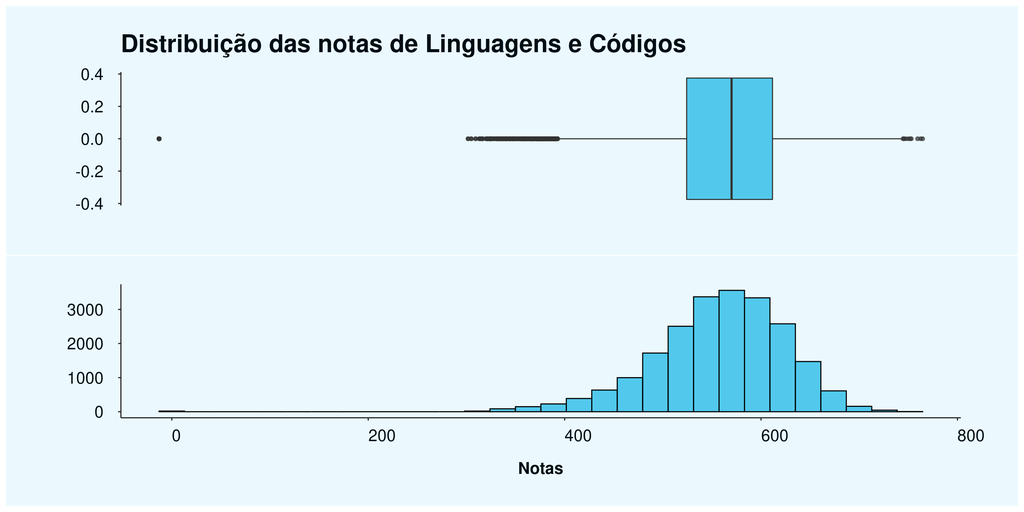

Gráfico 07 - BoxPlot e histograma da distribuição de notas de Linguagens e Códigos

```r
# Construir a visualização composta por dois gŕaficos por meio da biblioteca patchwork
# Boxplot para observarmos principalmente a média, notas mínimas e notas máximas
# Histogram para observarmos a distribuição das notas das redações

## gráfico_07_1 - boxplot das notas
p7_1 <- enem_cidade |>
  dplyr::select(nu_nota_lc) |>
  ggplot2::ggplot(ggplot2::aes(x = nu_nota_lc)) +
  ggplot2::geom_boxplot(
    fill = "#11B5E4",
    alpha = 0.7
  ) +
  ggplot2::labs(
    title = "Distribuição das notas de Linguagens e Códigos ",
    x = "",
    y = ""
  ) +
  ggplot2::theme_classic() +
  theme_enem() +
  ggplot2::theme(
    axis.ticks.x = ggplot2::element_blank(),
    axis.line.x = ggplot2::element_blank(),
    axis.text.x = ggplot2::element_blank()
  )
# gráfico do histograma das notas de linguagens e códigos (parte inferior da visualização)
p7_2 <- enem_cidade |>
  dplyr::select(nu_nota_lc) |>
  ggplot2::ggplot(ggplot2::aes(x = nu_nota_lc)) +
  ggplot2::geom_histogram(
    fill = "#11B5E4",
    color = "#000000",
    alpha = 0.7
  ) +
  ggplot2::labs(
    x = "Notas",
    y = ""
  ) +
  ggplot2::theme_classic() +
  theme_enem()

library(patchwork) # uso do pacote patchwork para união dos gráficos

# disposição dos gráficos
p7 <- p7_1 / p7_2
p7
```

A área de conhecimento “Linguagens e Códigos e suas Tecnologias” é composta pelas disciplinas de língua portuguesa, literatura, língua estrangeira (inglês ou espanhol), artes, educação física e tecnologias da informação e comunicação.

As notas variam de 0 a 1000. A maior nota obtida no município de Curitiba de **751.6** foi obtida por **1** aluno(s) e a nota média foi de **557.35**.

### Distribuição das Notas de Linguagens e Códigos por Intervalo de Classes.

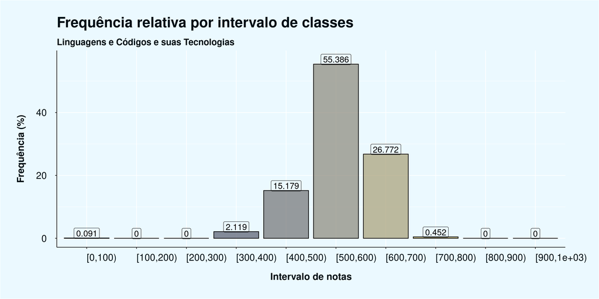

Gráfico_08_diagrama_colunas_notas_LC_por_intervalos

```r
p8 <- tab_classes_notas_lc |>
  ggplot2::ggplot() +
  ggplot2::aes(
    x = Var1,
    y = Freq,
    fill = Var1,
    label = round(Freq, 3)
  ) +
  ggplot2::geom_col(
    color = "#000000",
    alpha = 0.7
  ) +
  ggplot2::geom_label( # labels
    size = 5,
    color = "#000000",
    alpha = 0,
    nudge_y = 1.5
  ) +
  ggplot2::labs( # títulos dos eixos
    title = "Frequência relativa por intervalo de classes",
    subtitle = "Linguagens e Códigos e suas Tecnologias",
    x = "Intervalo de notas",
    y = "Frequência (%)"
  ) +
  ggplot2::scale_fill_viridis_d(option = "E") +
  ggplot2::theme(legend.position = "none") +
  theme_enem()

p8
```

No gráfico 08, pode-se visualizar como as notas desta área de conhecimento se distribuíram por intervalos de notas. Perceba que **82.158%** dos participante(s), ou seja, **17986** aluno(s) obtiveram notas nos intervalos **[600,700)** e **[500,600)**. Com relação às menores notas, tem-se que **0.091%** ou **20** aluno(s) obtiveram notas no intervalo de **[0,100)**.

### Médias das Notas por Dependência Administrativa em Linguagens e Códigos

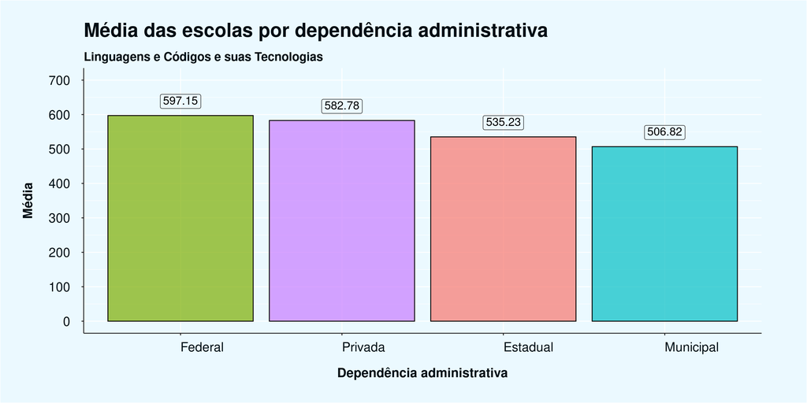

Gráfico 09 - Gráfico de colunas - médias por dependência administrativa em linguagens e códigos

```r
p9 <- notas_tipo_escola_lc |>
  ggplot2::ggplot() +
  ggplot2::aes(
    x = forcats::fct_reorder(
      tp_dependencia_adm_esc,
      medias,
      .desc = TRUE
    ),
    y = medias,
    fill = tp_dependencia_adm_esc,
    label = round(medias, 2)
  ) +
  ggplot2::geom_col(
    color = "#000000",
    alpha = 0.7
  ) +
  ggplot2::geom_label(
    size = 5,
    color = "#000000",
    alpha = 0,
    vjust = -0.5
  ) +
  ggplot2::labs(
    title = "Média das escolas por dependência administrativa",
    subtitle = "Linguagens e Códigos e suas Tecnologias",
    x = "Dependência administrativa",
    y = "Média"
  ) +
  ggplot2::theme(legend.position = "none") +
  ggplot2::scale_y_continuous(
    limits = c(0, 700),
    breaks = seq(0, 700, 100)
  ) +
  theme_enem()

p9
```

São quatro os tipos de dependência administrativa: estadual, municipal, federal ou privada.

O gráfico 9 apresenta as notas médias por tipo de dependência administrativa existente no município de Curitiba.

### Escolha da Língua Estrangeira

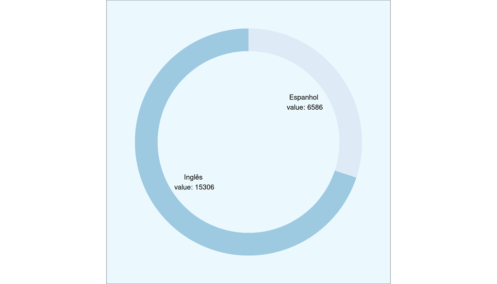

Gráfico 7_a - Gráfico donnut - línguas estrangeiras

O candidato deve optar por um dos dois idiomas disponíveis no momento da inscrição, inglês ou espanhol, não sendo possível a alteração da escolha posteriormente.

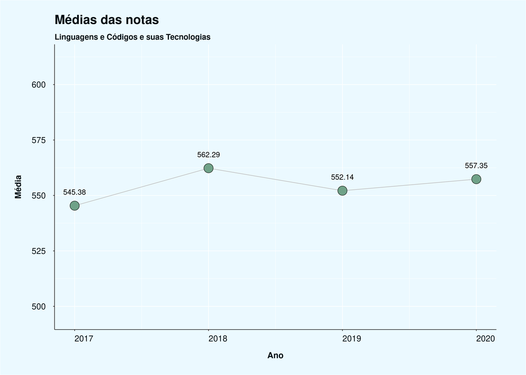

Gráfico 10 - Gráfico de linhas - evolução das notas de linguagens e códigos

```r
p10 <- enem_lc_historico |>
  ggplot2::ggplot() +
  ggplot2::aes(
    x = nu_ano,
    y = media,
    label = round(media, 2)
  ) +
  ggplot2::geom_line(color = "grey") +
  ggplot2::geom_point(
    shape = 21,
    color = "black",
    fill = "#70A288",
    size = 8
  ) +
  ggplot2::geom_text(
    vjust = -2,
    size = 5
  ) +
  theme_enem() +
  ggplot2::labs(
    title = "Médias das notas",
    subtitle = "Linguagens e Códigos e suas Tecnologias",
    x = "Ano",
    y = "Média"
  ) +
  ggplot2::scale_y_continuous(limits = c(
    min(enem_lc_historico$media) - 50,
    max(enem_lc_historico$media) + 50
  ))

p10
```

# Prova de Ciências da Natureza

### Distribuição das notas de Ciências da Natureza

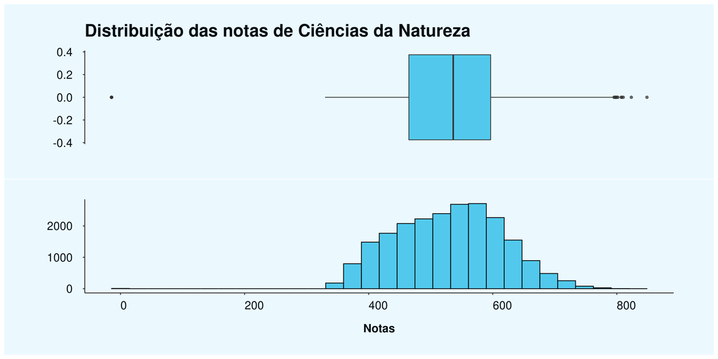

Gráfico 11 - BoxPlot e histograma da distribuição de notas de ciências da natureza

```r
# Construir a visualização composta por dois gŕaficos por meio da biblioteca patchwork
# Boxplot para observarmos principalmente a média, notas mínimas e notas máximas
# Histogram para observarmos a distribuição das notas das redações

## gráfico_11_1 - boxplot das notas
p11_1 <- enem_cidade |>
  dplyr::select(nu_nota_cn) |>
  ggplot2::ggplot(ggplot2::aes(x = nu_nota_cn)) +
  ggplot2::geom_boxplot(
    fill = "#11B5E4",
    alpha = 0.7
  ) +
  ggplot2::labs(
    title = "Distribuição das notas de Ciências da Natureza ",
    x = "",
    y = ""
  ) +
  ggplot2::theme_classic() +
  theme_enem() +
  ggplot2::theme(
    axis.ticks.x = ggplot2::element_blank(),
    axis.line.x = ggplot2::element_blank(),
    axis.text.x = ggplot2::element_blank()
  )
# gráfico do histograma das notas das redações (parte inferior da visualização)
p11_2 <- enem_cidade |>
  dplyr::select(nu_nota_cn) |>
  ggplot2::ggplot(ggplot2::aes(x = nu_nota_cn)) +
  ggplot2::geom_histogram(
    fill = "#11B5E4",
    color = "#000000",
    alpha = 0.7
  ) +
  ggplot2::labs(
    x = "Notas",
    y = ""
  ) +
  ggplot2::theme_classic() +
  theme_enem()

library(patchwork) # uso do pacote patchwork para união dos gráficos

# disposição dos gráficos
p11 <- p11_1 / p11_2
p11
```

A área de conhecimento “Ciências da Natureza e suas Tecnologias” é composta pelas disciplinas de química, física e biologia.

As notas variam de 0 a 1000. A maior nota obtida no município de Curitiba de **834.1** foi obtida por **1** aluno(s) e a nota média foi de **528.75**.

### Distribuição das notas de Ciências da Natureza por intervalo de classes.

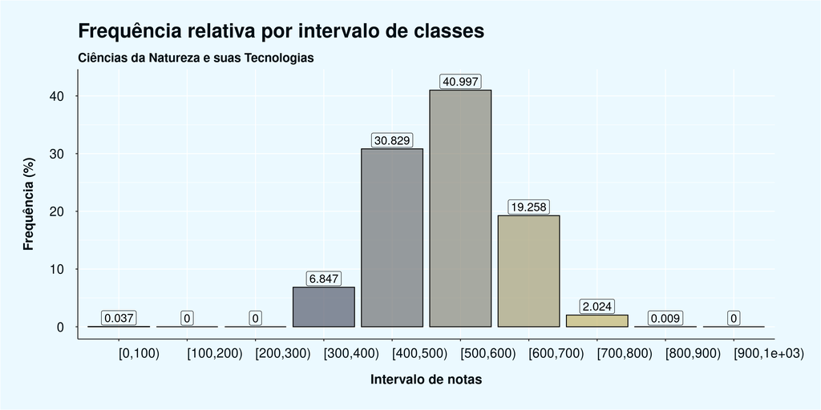

Gráfico_09_diagrama_colunas_notas_CN_por_intervalos

```r
p12 <- tab_classes_notas_cn |>
  ggplot2::ggplot() +
  ggplot2::aes(
    x = Var1,
    y = Freq,
    fill = Var1,
    label = round(Freq, 3)
  ) +
  ggplot2::geom_col(
    color = "#000000",
    alpha = 0.7
  ) +
  ggplot2::geom_label( # labels
    size = 5,
    color = "#000000",
    alpha = 0,
    nudge_y = 1.5
  ) +
  ggplot2::labs( # títulos dos eixos
    title = "Frequência relativa por intervalo de classes",
    subtitle = "Ciências da Natureza e suas Tecnologias",
    x = "Intervalo de notas",
    y = "Frequência (%)"
  ) +
  ggplot2::scale_fill_viridis_d(option = "E") +
  ggplot2::theme(legend.position = "none") +
  theme_enem()

p12
```

No gráfico 09, pode-se visualizar como as notas desta área de conhecimento se distribuíram por intervalos de notas. Perceba que **71.825%** dos participante(s), ou seja, **15724** aluno(s) obtiveram notas nos intervalos **[400,500)** e **[500,600)**. Com relação às menores notas, tem-se que **0.037%** ou **8** aluno(s) obtiveram notas no intervalo de **[0,100)**.

### Médias das notas por dependência administrativa

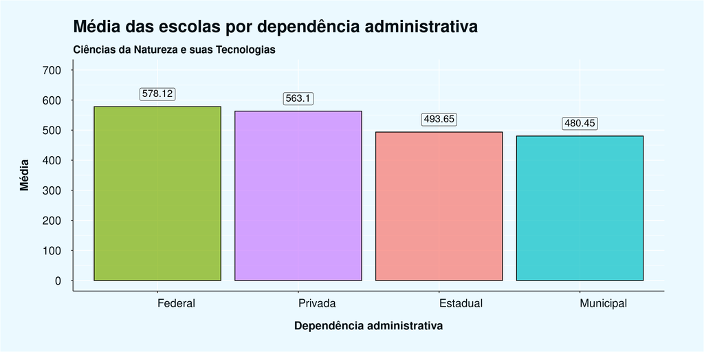

Gráfico 10 - Gráfico de colunas - médias por dependência administrativa na prova de Ciências da Natureza

```r
p13 <- notas_tipo_escola |>
  ggplot2::ggplot() +
  ggplot2::aes(
    x = forcats::fct_reorder(
      tp_dependencia_adm_esc,
      medias,
      .desc = TRUE
    ),
    y = medias,
    fill = tp_dependencia_adm_esc,
    label = round(medias, 2)
  ) +
  ggplot2::geom_col(
    color = "#000000",
    alpha = 0.7
  ) +
  ggplot2::geom_label(
    size = 5,
    color = "#000000",
    alpha = 0,
    vjust = -0.5
  ) +
  ggplot2::labs(
    title = "Média das escolas por dependência administrativa",
    subtitle = "Ciências da Natureza e suas Tecnologias",
    x = "Dependência administrativa",
    y = "Média"
  ) +
  ggplot2::theme(legend.position = "none") +
  ggplot2::scale_y_continuous(
    limits = c(0, 700),
    breaks = seq(0, 700, 100)
  ) +
  theme_enem()

p13
```

São quatro os tipos de dependência administrativa: estadual, municipal, federal ou privada.

O gráfico 10 apresenta as notas médias por tipo de dependência administrativa existente no município de Curitiba.

### Evolução das notas de Ciências da Natureza nos últimos anos

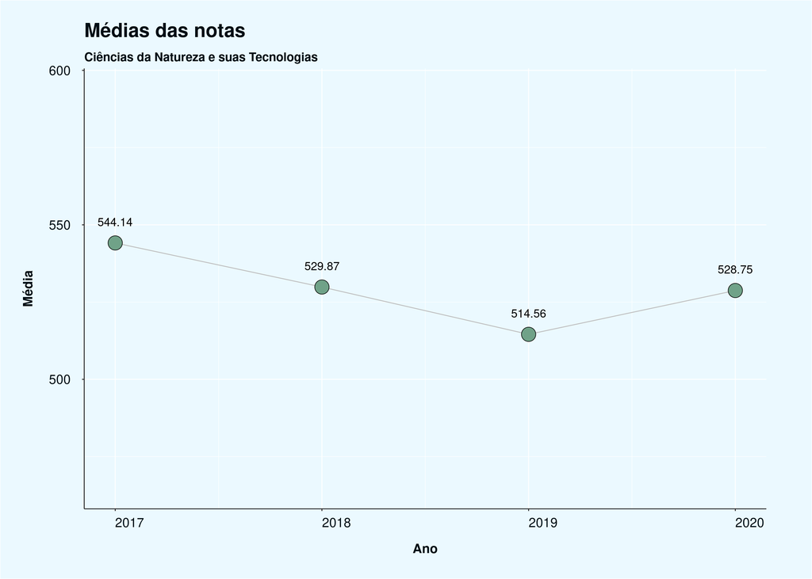

Gráfico 11 - Gráfico de linhas - evolução das notas de Ciências da Natureza

```r
p11 <- enem_cn_historico |>
  ggplot2::ggplot() +
  ggplot2::aes(
    x = nu_ano,
    y = media,
    label = round(media, 2)
  ) +
  ggplot2::geom_line(color = "grey") +
  ggplot2::geom_point(
    shape = 21,
    color = "black",
    fill = "#70A288",
    size = 8
  ) +
  ggplot2::geom_text(
    vjust = -2,
    size = 5
  ) +
  theme_enem() +
  ggplot2::labs(
    title = "Médias das notas",
    subtitle = "Ciências da Natureza e suas Tecnologias",
    x = "Ano",
    y = "Média"
  ) +
  ggplot2::scale_y_continuous(limits = c(
    min(enem_cn_historico$media) - 50,
    max(enem_cn_historico$media) + 50
  ))

p11
```

# Prova de Ciências Humanas

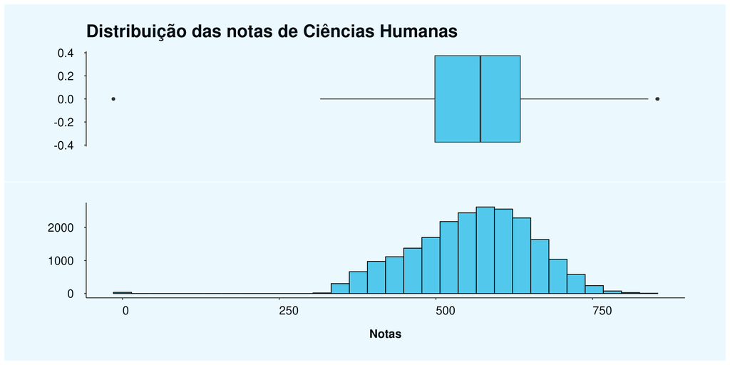

Gráfico 12 - BoxPlot e histograma da distribuição de notas de ciências humanas

```r
## gráfico_12_1 - boxplot das notas
p12_1 <- enem_cidade |>
  dplyr::select(nu_nota_ch) |>
  ggplot2::ggplot(ggplot2::aes(x = nu_nota_ch)) +
  ggplot2::geom_boxplot(
    fill = "#11B5E4",
    alpha = 0.7
  ) +
  ggplot2::labs(
    title = "Distribuição das notas de Ciências Humanas ",
    x = "",
    y = ""
  ) +
  ggplot2::theme_classic() +
  theme_enem() +
  ggplot2::theme(
    axis.ticks.x = ggplot2::element_blank(),
    axis.line.x = ggplot2::element_blank(),
    axis.text.x = ggplot2::element_blank()
  )
# gráfico do histograma das notas das redações (parte inferior da visualização)
p12_2 <- enem_cidade |>
  dplyr::select(nu_nota_ch) |>
  ggplot2::ggplot(ggplot2::aes(x = nu_nota_ch)) +
  ggplot2::geom_histogram(
    fill = "#11B5E4",
    color = "#000000",
    alpha = 0.7
  ) +
  ggplot2::labs(
    x = "Notas",
    y = ""
  ) +
  ggplot2::theme_classic() +
  theme_enem()

library(patchwork) # uso do pacote patchwork para união dos gráficos

# disposição dos gráficos
p12 <- p12_1 / p12_2
p12
```

A área de conhecimento “Ciências Humanas e suas Tecnologias” é composta pelas disciplinas de história, geografia, filosofia e sociologia

A maior nota obtida no município de Curitiba de **839.5** foi obtida por **6** aluno(s) e a nota média foi de **558.72**.

### Distribuição das notas de Ciências Humanas por intervalo de classes.

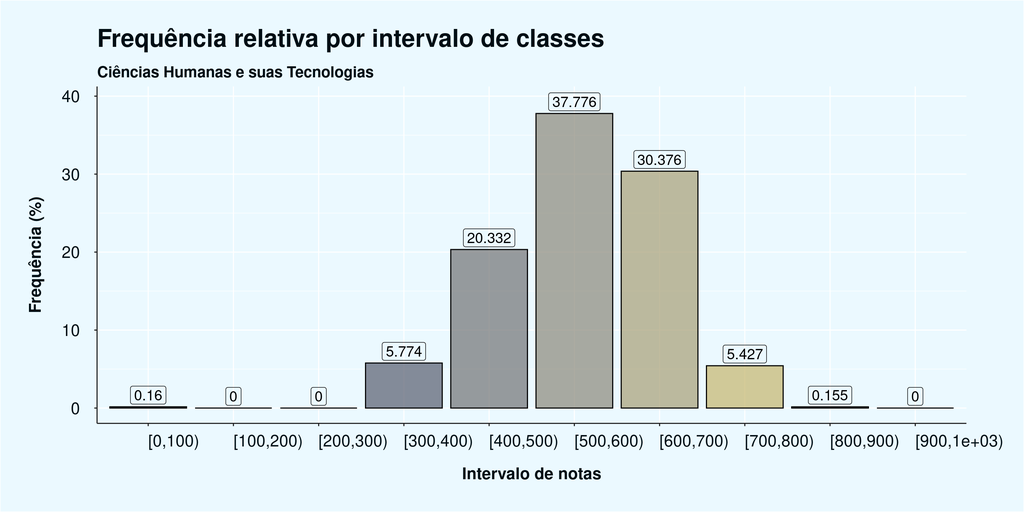

Gráfico 13 - Diagrama de colunas das notas de Ciências Humanas por intervalos

```r
p13 <- tab_classes_notas_ch |>
  ggplot2::ggplot() +
  ggplot2::aes(
    x = Var1,
    y = Freq,
    fill = Var1,
    label = round(Freq, 3)
  ) +
  ggplot2::geom_col(
    color = "#000000",
    alpha = 0.7
  ) +
  ggplot2::geom_label( # labels
    size = 5,
    color = "#000000",
    alpha = 0,
    nudge_y = 1.5
  ) +
  ggplot2::labs( # títulos dos eixos
    title = "Frequência relativa por intervalo de classes",
    subtitle = "Ciências Humanas e suas Tecnologias",
    x = "Intervalo de notas",
    y = "Frequência (%)"
  ) +
  ggplot2::scale_fill_viridis_d(option = "E") +
  ggplot2::theme(legend.position = "none") +
  theme_enem()

p13
```

No gráfico 13, pode-se visualizar como as notas desta área de conhecimento se distribuíram por intervalos de notas. Perceba que **68.153%** dos participante(s), ou seja, **14920** aluno(s) obtiveram notas nos intervalos **[600,700)** e **[500,600)**. Com relação às menores notas, tem-se que **0.16%** ou **35** aluno(s) obtiveram notas no intervalo de **[0,100)**.

### Médias das notas por dependência administrativa

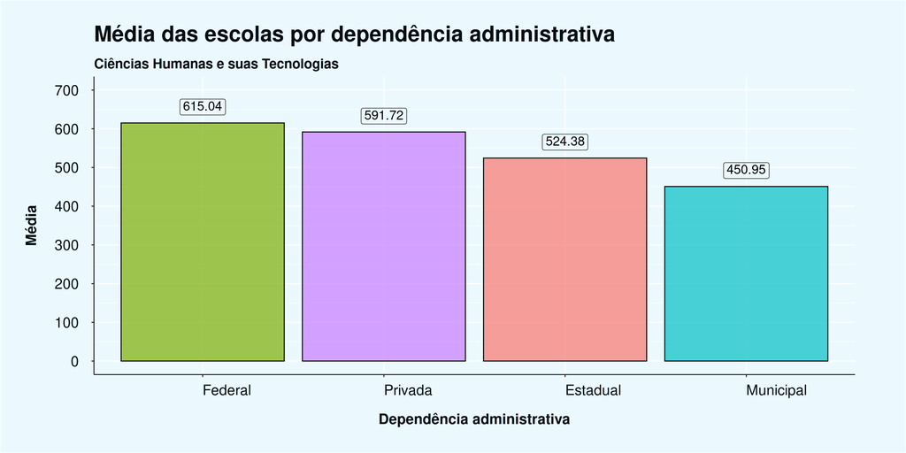

```r
p14 <- notas_tipo_escola_ch |>
  ggplot2::ggplot() +
  ggplot2::aes(
    x = forcats::fct_reorder(
      tp_dependencia_adm_esc,
      medias,
      .desc = TRUE
    ),
    y = medias,
    fill = tp_dependencia_adm_esc,
    label = round(medias, 2)
  ) +
  ggplot2::geom_col(
    color = "#000000",
    alpha = 0.7
  ) +
  ggplot2::geom_label(
    size = 5,
    color = "#000000",
    alpha = 0,
    vjust = -0.5
  ) +
  ggplot2::labs(
    title = "Média das escolas por dependência administrativa",
    subtitle = "Ciências Humanas e suas Tecnologias",
    x = "Dependência administrativa",
    y = "Média"
  ) +
  ggplot2::theme(legend.position = "none") +
  ggplot2::scale_y_continuous(
    limits = c(0, 700),
    breaks = seq(0, 700, 100)
  ) +
  theme_enem()

p14
```

### Evolução das notas de Ciências Humanas nos últimos anos

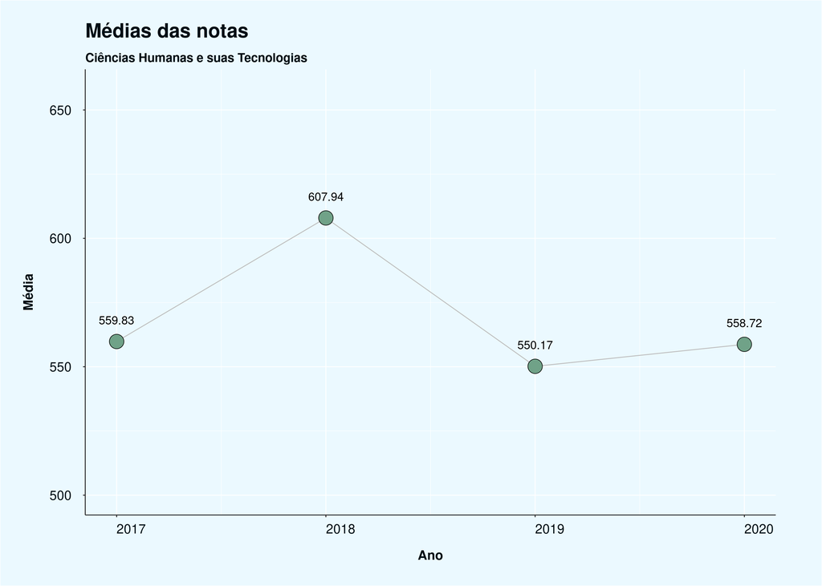

Gráfico 15 - Gráfico de linhas - evolução das notas de CH

```r
p15 <- enem_ch_historico |>
  ggplot2::ggplot() +
  ggplot2::aes(
    x = nu_ano,
    y = media,
    label = round(media, 2)
  ) +
  ggplot2::geom_line(color = "grey") +
  ggplot2::geom_point(
    shape = 21,
    color = "black",
    fill = "#70A288",
    size = 8
  ) +
  ggplot2::geom_text(
    vjust = -2,
    size = 5
  ) +
  theme_enem() +
  ggplot2::labs(
    title = "Médias das notas",
    subtitle = "Ciências Humanas e suas Tecnologias",
    x = "Ano",
    y = "Média"
  ) +
  ggplot2::scale_y_continuous(limits = c(
    min(enem_ch_historico$media) - 50,
    max(enem_ch_historico$media) + 50
  ))

p15
```